# What goes together with happiness?

To start the app, open this file in RStudio and run the chunk below (the green arrow at its top right). Knitting the file only shows the code, because an app cannot run inside a static HTML page.

```r
shiny::runApp(happiness_app(
  combined_data, available_predictors,
  predictor_groups = group_predictors(available_predictors),
  predictor_notes = predictor_notes,
  variable_info = variable_info
))
```

## Analyse the data

**Research question**

Does the relationship between social support and happiness differ between continents, after controlling for Logged GDP per capita?

**Data and method**

We use country-level happiness data from the World Happiness Report 2023 (Helliwell et al., 2023; Singh, 2023). Happiness is the outcome, social support is the primary predictor, continent is the moderator, and Logged GDP per capita is the control variable.

We fit a linear regression with an interaction between social support and continent. This allows the association between social support and happiness to differ between continents. The overall interaction test evaluates whether these differences improve the model compared with a model without the interaction.

We use HC3 robust standard errors, which allow the residual spread to vary between countries (Long & Ervin, 2000). Countries with missing or nonfinite values are excluded. Continents with fewer than five countries with complete data are also excluded.

```r
social_support_result <- analyse_happiness(
  primary_predictor = "Social support",
  moderator = "continent",
  control_variables = "Logged GDP per capita"
)
```

**Visualisation**

The points represent the observed countries. Each continent has its own fitted line and 95% confidence band. For these predictions, Logged GDP per capita is held at its mean across the countries included in the analysis. The lines are restricted to the social support values observed within each continent.

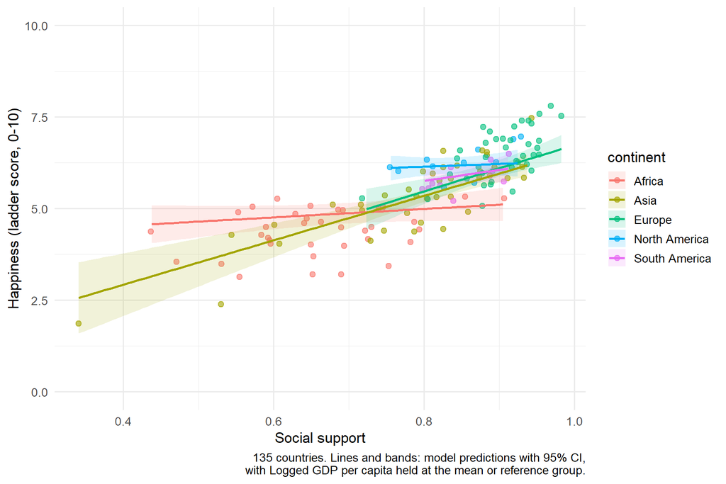

```r
plot_happiness(social_support_result)
```

**Results**

The coefficient table shows the estimated associations and their confidence intervals. The social support coefficient is the slope for the reference continent. Interaction coefficients show how the slopes of other continents differ from that reference.

```r
knitr::kable(format_coefficients(social_support_result))
```

| Term | Estimate | 95% CI | p |
| --- | --- | --- | --- |
| Intercept | 0.847 | [-0.656, 2.350] | .267 |
| Social support | 1.152 | [-0.542, 2.846] | .181 |
| continent [Asia] | -3.576 | [-5.401, -1.751] | < .001 |
| continent [Europe] | -3.661 | [-6.605, -0.718] | .015 |
| continent [North America] | 1.477 | [-1.316, 4.271] | .297 |
| continent [South America] | -0.710 | [-4.812, 3.392] | .732 |
| Logged GDP per capita | 0.342 | [0.185, 0.499] | < .001 |
| Social support x continent [Asia] | 4.917 | [2.472, 7.361] | < .001 |
| Social support x continent [Europe] | 5.174 | [1.696, 8.651] | .004 |
| Social support x continent [North America] | -0.404 | [-3.936, 3.128] | .821 |
| Social support x continent [South America] | 1.846 | [-3.107, 6.799] | .462 |

The summary below reports the overall interaction test and describes whether there is evidence that the association differs between continents.

```r
cat(
  paste(describe_result(social_support_result), collapse = "\n\n"),
  "\n"
)
```

Based on 135 countries (0 excluded because of missing data).

Left out: Oceania (a group of continent), because it has fewer than 5 countries with data.

Controlling for Logged GDP per capita: the results compare countries that are equal on it.

Adding the interaction between Social support and continent significantly improves the model (F(4, 124) = 5.97, p < .001).

So the association between Social support and happiness differs depending on continent.

Standard errors, confidence intervals and p-values are robust (HC3): they do not assume that the spread around the line is the same for every country.

These are country-level associations: they do not show causal effects or effects on individual people.

**Limitations**

These are observational, country-level associations. They do not establish causation or show that the same relationships hold for individuals. Adjusting for GDP does not remove all possible confounding. Small continent groups can produce imprecise estimates, and HC3 standard errors do not correct for spatial dependence between countries.

## Assumption checks

The regression assumptions are checked for every predictor in the simple model happiness ~ predictor (README, Methods). The counts:

```r
assumption_checks <- check_assumptions()
knitr::kable(assumption_checks$summary)
```

| check | predictors | out_of |
| --- | --- | --- |
| Unequal spread (Breusch-Pagan) | 4 | 35 |
| HC3 standard errors at least 20% larger | 5 | 35 |
| Significance conclusion changes with HC3 | 2 | 35 |
| Non-normal residuals (Shapiro-Wilk) | 22 | 35 |
| Extreme country (Cook’s distance above 1) | 2 | 35 |
| Curve fits better than a straight line | 14 | 34 |
| Straight line misleading (the app’s warning) | 7 | 34 |

We assess spatial dependence in the residuals using Moran’s I, comparing models with and without continent as a control (Moran, 1950):

```r
knitr::kable(assumption_checks$spatial, digits = 3)
```

| predictor | i_alone | p_alone | i_with_continent | p_with_continent |
| --- | --- | --- | --- | --- |
| Social support | 0.076 | 0 | 0.044 | 0.000 |
| Logged GDP per capita | 0.085 | 0 | 0.007 | 0.137 |
| Freedom to make life choices | 0.161 | 0 | 0.017 | 0.032 |
| Healthy life expectancy | 0.061 | 0 | 0.018 | 0.026 |

For selected predictors, we include continent as a control and calculate standard errors clustered by continent (Zeileis et al., 2020). These are robustness checks for separate models, not the moderation model above. Interpret them cautiously because the number of clusters is small:

```r
knitr::kable(assumption_checks$clustered, digits = 3)
```

| predictor | estimate | se_hc3 | se_clustered | clusters | p_clustered |
| --- | --- | --- | --- | --- | --- |
| Social support | 5.723 | 0.777 | 1.661 | 6 | 0.018 |
| Logged GDP per capita | 0.566 | 0.110 | 0.127 | 6 | 0.007 |
| Freedom to make life choices | 4.197 | 0.962 | 0.746 | 6 | 0.002 |
| Healthy life expectancy | 0.108 | 0.025 | 0.024 | 6 | 0.006 |

## References

Helliwell, J. F., Layard, R., Sachs, J. D., Aknin, L. B., De Neve, J.-E., & Wang, S. (Eds.). (2023). *World Happiness Report 2023* (11th ed.). Sustainable Development Solutions Network. https://worldhappiness.report/ed/2023/

Long, J. S., & Ervin, L. H. (2000). Using heteroscedasticity consistent standard errors in the linear regression model. *The American Statistician*, *54*(3), 217–224. https://doi.org/10.1080/00031305.2000.10474549

Moran, P. A. P. (1950). Notes on continuous stochastic phenomena. *Biometrika*, *37*(1/2), 17–23. https://doi.org/10.2307/2332142

Singh, A. (2023). *World Happiness Report 2023* [Data set]. Kaggle. https://www.kaggle.com/datasets/ajaypalsinghlo/world-happiness-report-2023

Zeileis, A., Köll, S., & Graham, N. (2020). Various versatile variances: An object-oriented implementation of clustered covariances in R. *Journal of Statistical Software*, *95*(1), 1–36. https://doi.org/10.18637/jss.v095.i01